# On the Effectiveness of Face Masks in the General Population

Dane Van Domelen

March 23, 2020

### Background

American public health agencies currently recommend face masks to protect against coronavirus transmission for healthcare providers (HCP’s) but not the general public. The rationale is that masks are more effective for HCP’s because the level of exposure is so much greater. Allocating a scarce resource to those at highest risk is intuitive, but the claim that masks are “less effective” for people with lower risk warrants inspection.

### Defining effectiveness

The effectiveness of an intervention is typically quantified by comparing risks with vs. without the intervention of interest. Two metrics are commonly used: **risk ratio (RR)** and **risk difference (RD)**. For example, if an individual’s risk for COVID-19 was 1/10000 with a mask and 2/10000 without, the effectiveness of masks could be described as $RR = 0.5$ and $RD = -0.0001$.

The statement “masks are more effective in HCP’s” corresponds to either $RR_{hcp} < RR_{gen}$ or $RD_{hcp} < RD_{gen}$, depending on which metric you think better reflects effectiveness.

### Notation

For a simple but sensible framework, suppose each person has some number of close interactions with infected people (could be 0), and each interaction carries the same fixed probability of transmission. We can define the following events:

- $D_{ij}$ = Person $i$ becomes infected during interaction $j$, $j \in {1, ..., n_i}$
- $D_i$ = Person $i$ becomes infected due to any of the $n_i$ interactions

### Probability of infection

The event $D_i$ is the complement of $\bar{D}_i$ = Person $i$ does not become infected. $\bar{D}_i$ can be expressed as $\bar{D}_{i1} \cap \bar{D}_{i2} \cap ... \cap \bar{D}_{in_i}$, or more compactly as $\cap_{j=1}^{n_i} \bar{D}_{ij}$. The probability of infection as a function of $n_i$ is:

$$\begin{equation}
\tag{Eq. 1}
P(D_i|n_i) = 1 - P(\bar{D}_i|n_i)
= 1 - P(\cap_{j=1}^{n_i} \bar{D}_{ij})
= 1 - \prod_{j=1}^{n_i} P(\bar{D}_{ij})
= 1 - [P(\bar{D}_{i1})]^{n_i}
\end{equation}$$

Note that we used two simplifying assumptions here: (1) equal probability of transmission across interactions, and (2) independent transmission occurrence across interactions.

### Effectiveness vs. number of interactions

Let $p = P(D_{i1}|\text{no mask})$ and $p_m = P(D_{i1}|\text{mask})$. Plugging these constants into Eq. 1 leads to:

$$\begin{equation}
\begin{aligned}
& P(D_i|n_i, \text{no mask}) = 1 - p^{n_i} \\
\\
& P(D_i|n_i, \text{mask}) = 1 - p_m^{n_i}
\end{aligned}
\end{equation}$$

The effectiveness metrics as a function of $n_i$ are:

$$\begin{equation}
\tag{Eq. 2}
RR(n_i) = \frac{1 - p_m^{n_i}}{1 - p^{n_i}}
\end{equation}$$

$$\begin{equation}
\tag{Eq. 3}
RD(n_i) = p^{n_i} - p_m^{n_i}
\end{equation}$$

$RR(n_i)$ is a monotone increasing function of $n_i$, converging to 1 as $n_i \to \infty$. Thus according to the RR, masks are *less* effective with increasing exposure – i.e., they would have a greater protective effect in the general population.

$RD(n_i)$ is not monotone in $n_i$, but minimized at $n_i$ that depends on $p$ and $p_m$. I believe over a plausible range of $n_i$, $RD$ will tend to sharply decrease with $n_i$, meaning masks are far more effective for people with more interactions (HCP’s).

To reconcile these results with an example: if face masks reduce probability of infection by say 70% for HCP’s, they reduce probability of infection by >70% for members of the general public. But if they reduce probability of infection by 0.0001 for HCP’s, they reduce the probability by <0.0001 for members of the general public.

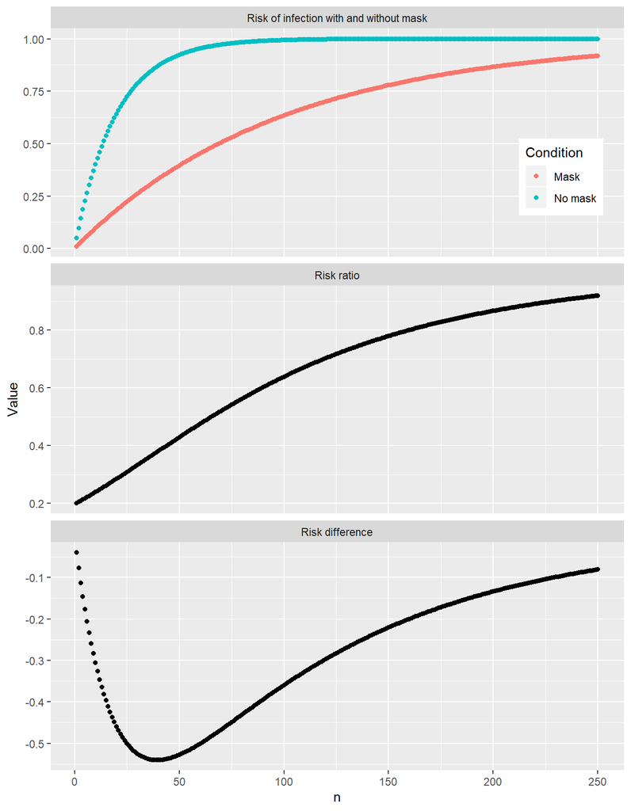